# Geospatial Data Analysis

**Intro the data and project**  
The Bigfoot is a mythical creature described in North American folklore, said to inhabit remote jungles. It first appeared in the Humboldt Times in 1958, when journalist Andrew Genzoli filmed a giant primate footprint found next to a bulldozer and named it Bigfoot. Our project is verifying the biological characteristics of Bigfoot and try to find connection between economic (or social) indicators and sightings from the data set that assembled by the Bigfoot Field Researchers Organization[BFRO](http://www.bfro.net/GDB/classify.asp). The data set contains 4747 records of Bigfoot sighting in the US. Besides the geospatial data, this data set also include the variables: date of sighting, classification which is a standard made by BFRO to classified the clarity of the sighting, and descriptions of location and situation of the sighting.  
**Methodology**  
Base on the data set from BFRO, we plan to conduct word cloud,bar plot for finding Bigfoot's height,Geospatial map of sightings, time series and scatter plot. We plan to use word clouds to find Bigfoot's habitat characteristics. The word cloud are extracted from the description variable that are at least five letters long. The stopwords are "english" stopwords from nltk.corpus package adding several additional words such as "would" and "could". For Bigfoot's height, we extracted the phrases about Bigfoots height 5 to 9 feet tall, such as "7 feet tall", "8' tall", from the description variable and created a bar plot showing the perceived height of Bigfoots. We use the map to help us identify where Bigfoot sightings occur frequently. Finally, we will use scatter plots to see if Bigfoot sightings correlate with county-level economic and social indicators.

**Presentation of result**

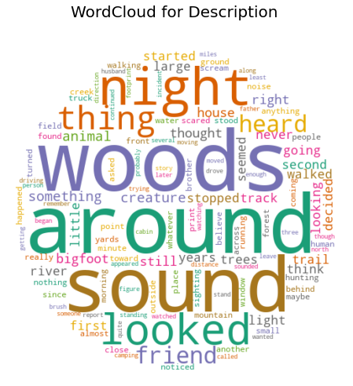

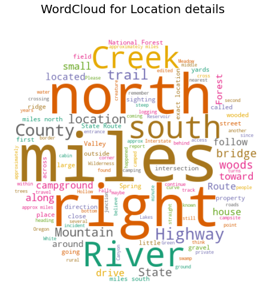

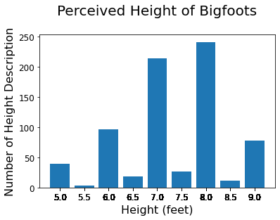

The bar plot shows Height record in the data set. According to the plot, we believe that the height of Bigfoot is probably between 7 feet to 8 feet tall.

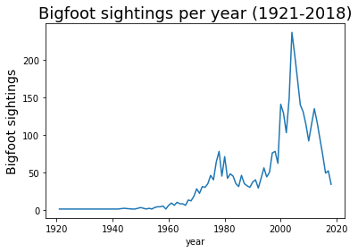

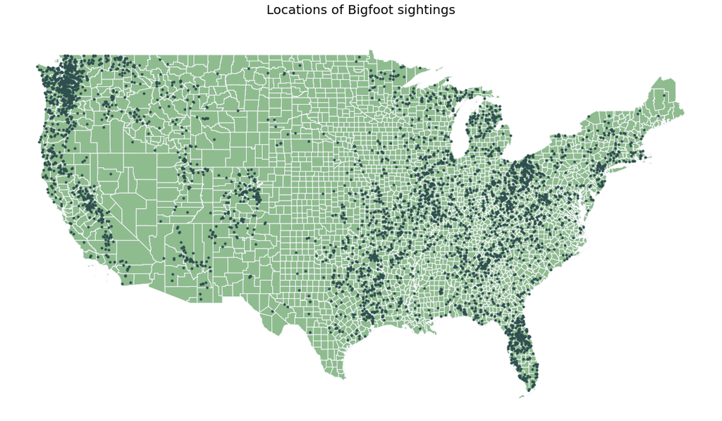

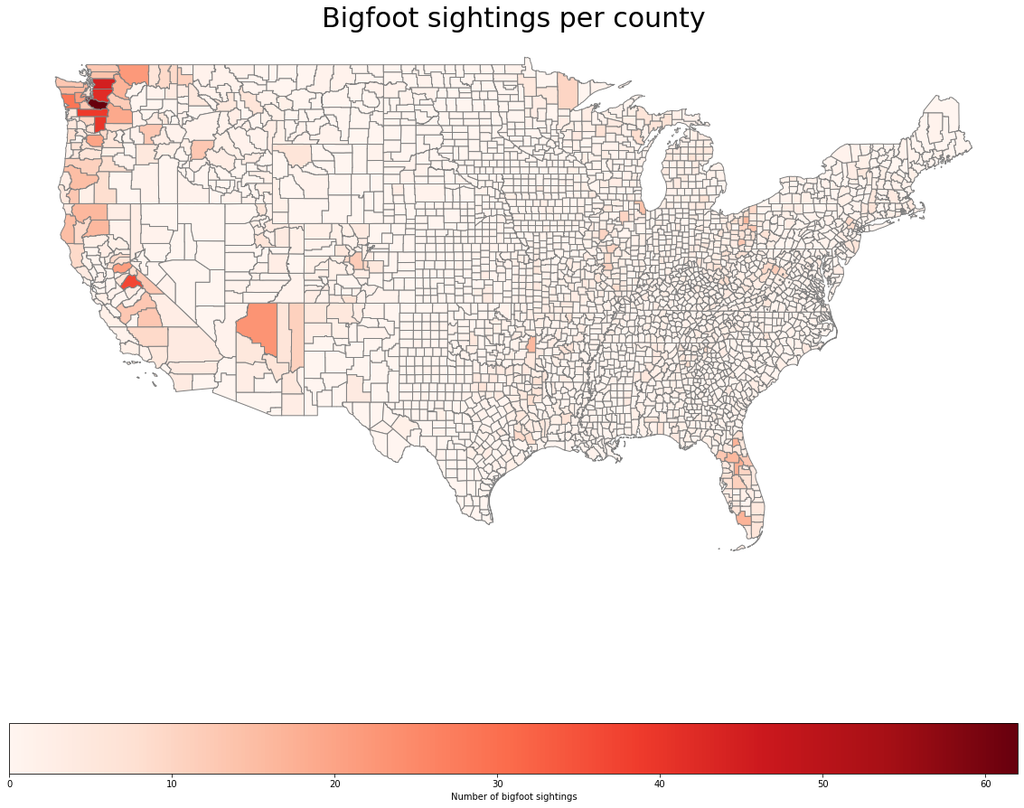

According to the map, we found that Bigfoot sightings are widely distributed in the eastern and western United States, which is highly correlated with the high-frequency words fed back by wordcloud. The central United States is plain, while the east and west have extensive mountainous terrain with higher elevations. The states with the most sightings, Washington, Oregon, California and Arizona, have vast forested areas and high-altitude landforms. This is also corroborated by the results of wordcloud feedback.

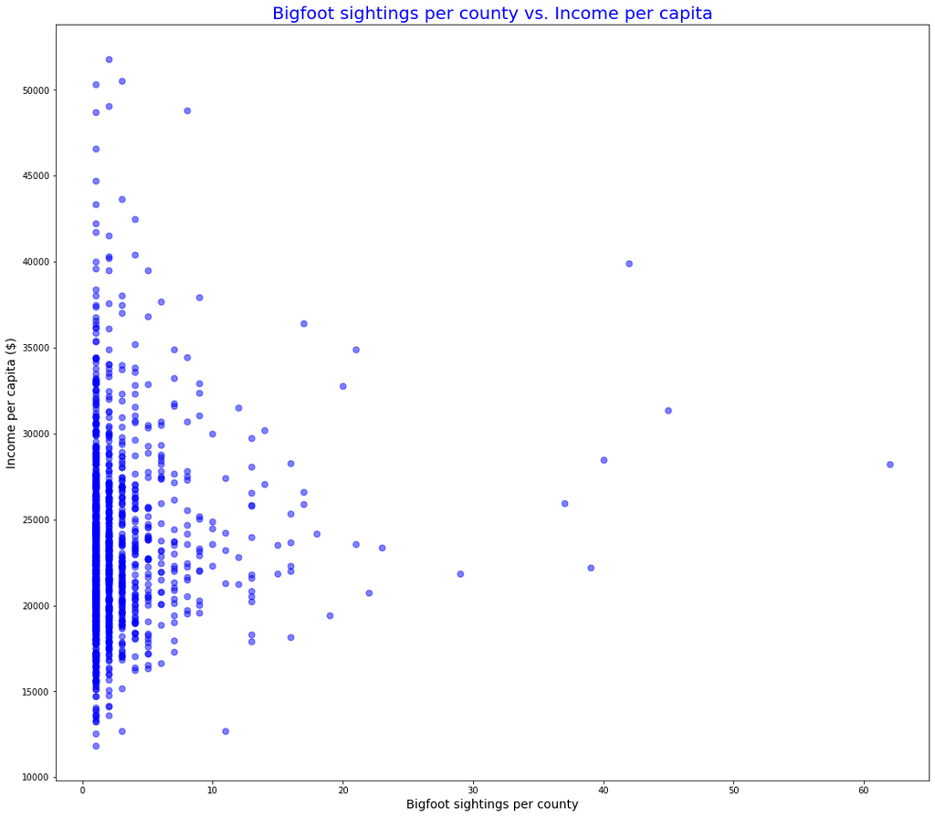

By looking at the scatterplot of the number of sightings and county-level per capita income, we didn’t find a very clear correlation. If we only look at counties with more than 10 sightings, we find that a large number of sightings are concentrated in the middle-income range. This may be because counties in the high-income bracket have higher-than-standard frequencies of human activity. Forests and mountains are widely distributed in counties in the middle-income range. According to the information obtained by wordcloud, the habitat of Bigfoot is more in line with the geographical characteristics of counties in the middle-income range.

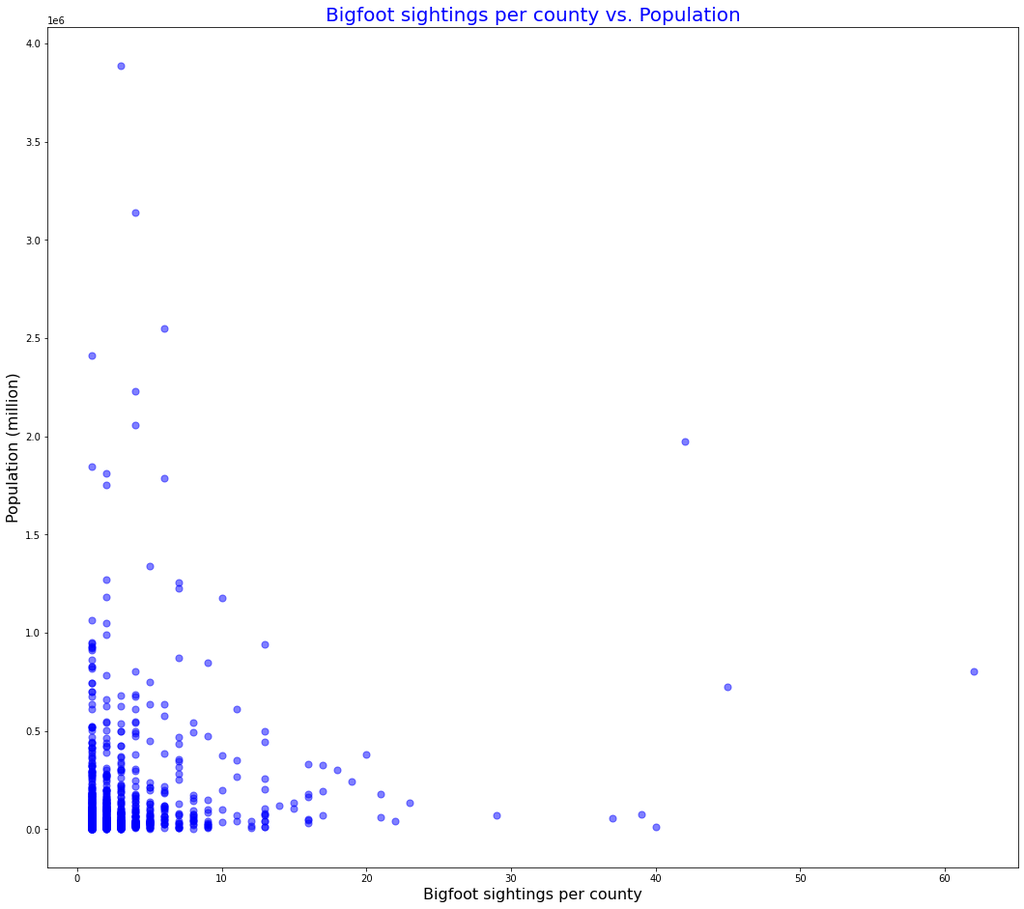

From he scatterplot of the number of sightings and county-level population, we did not find a very clear correlation.We drop population > 5000000 due to they are outliers.Through the density and distribution of observation points, we can observe that counties with lower populations have more sightings, which is consistent with the characteristics of Bigfoot preferring to live in remote places obtained by wordcloud.